# Project 2 - phase 2

Magda Młynarczyk, Dariusz Matlak, Zuzanna Kasprowicz

# 1 Intorduction and preparing dataset

Our goal, in second phase, was to create a model that can predict number of cancer cases in future. The dataset contains information about number of cancer cases for different regions, genders and age groups. To our analysis we chose a packet of cancers which are common among women: breast cancer, thyroid and ovarian cancer. We also decided to work with voivodeships and predict the number of cancers in stage $4$.

We used libraries such as:

```r
library(data.table)
library(dplyr)
library(ggplot2)
library(lattice)
library(tidyr)
library(raster)
library(e1071)
library(glmnet)
library(caret)
library(boot)
library(sp)
library(rgdal)
library(rgeos)
library(gdata)
library(maptools)
library(RColorBrewer)
library(mapoland)
library(mapmisc)
library(classInt)
library(gridExtra)
library(mapmisc)
library(colorspace)
```

First we prepared dataset to make it more clear:

1. We chose cancer: C50_D05, C56, C73.
2. We changed the class of AGE-GROUP.
3. We removed columns with information about gender, type of cancer and counties.
4. Finally we got data table: rak.

```r
head(rak)
```

```
##   Gender Wojewodztwo  Age Year sumStage1 sumStage2 sumStage3    Y
## 1      K           2 0-44 2010     44.20     73.05     57.85 21.9
## 2      K           2 0-44 2011     44.25     74.35     67.00 34.4
## 3      K           2 0-44 2012     53.25     78.15     65.00 16.6
## 4      K           4 0-44 2010     12.40     80.90     46.40 25.3
## 5      K           4 0-44 2011     22.95     86.80     48.65 13.6
## 6      K           4 0-44 2012     17.20     90.80     55.90 15.1
```

We were also trying to find factors that influence the number of cancer cases. Maybe it is salaries in region or air pollution, maybe something else.

Let’s find out!!!

# 2 Searching for the best model.

To prepare a model firstly we divided our data set into two: training and testing set. For testing set we chose observations from $2012$ year. For traing set - the rest of main data - observations from $2010$ and $2011$. All in all, from main set with $557$ observations we got two: test set with $185$ observations and train set with $372$ observations. Our output variable is Stage $4$.

```r
test <- filter(rak, Year == 2012)
test <- test[,!"Year", with = FALSE]
train <- filter(rak, Year != 2012)
train <- train[, !"Year", with = FALSE]
```

During creating a model, we were trying different approaches - to choose the best result. We used {glmnet} library to perform cross-validation so as to choose optimal parameter. Next we collated mean square errors of each model.

**1. The lasso**

Our first model is the lasso. We used cross-validation to set the parameter - lambda. Let’s see the plot which includes the cross-validation curve (red dotted line), and upper and lower standard deviation curves along the $\lambda$ sequence (error bars). Two selected $\lambda$’s are indicated by the vertical dotted lines

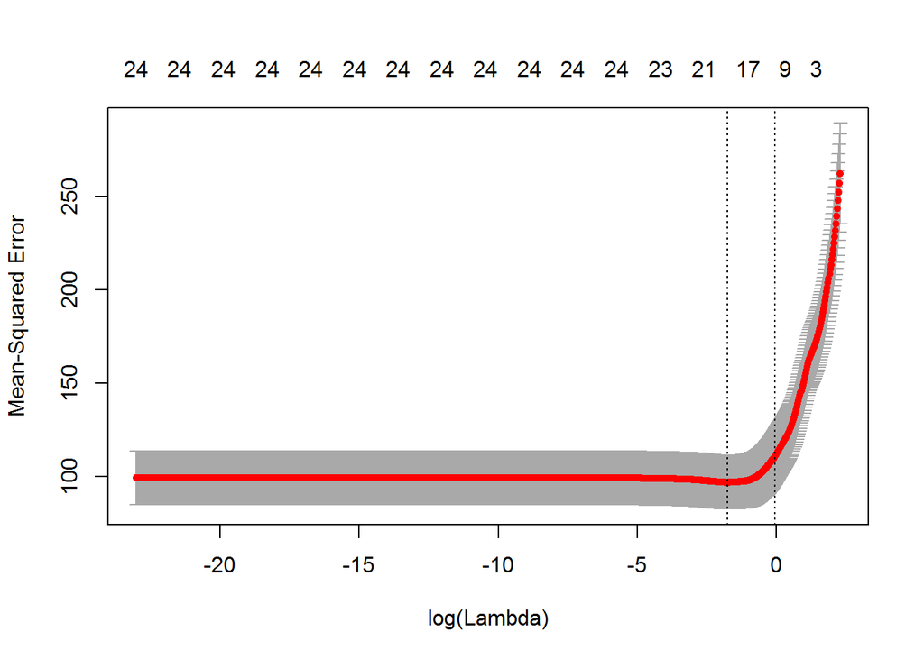

We can view the selected $\lambda$’s, named lambda.min: `0.1730766`. Lambda.min is the value of $\lambda$ that gives minimum mean cross-validated error. For that $\lambda$ we performed prediction and calculate the mean square error - the difference between the estimator and what is estimated: `114.0721429`.

**2. Ridge regression**

We did the same for the second model - the ridge. We obtained:

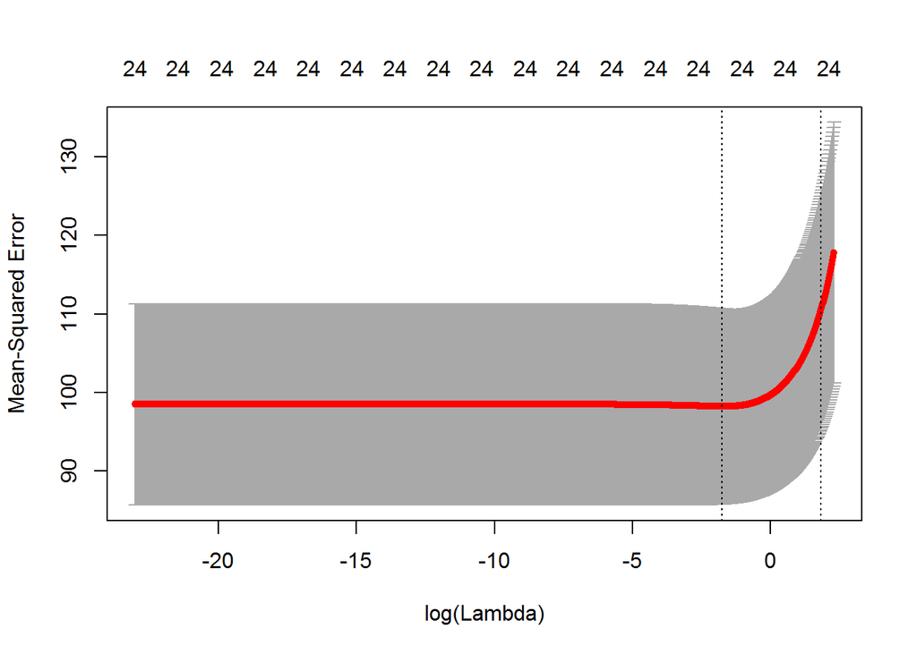

The min lambda is: `0.1730766`, mean square error: `113.1687197`.

**3. Lasso and ridge**

The last, but not least is the mixture of lasso and ridge model.

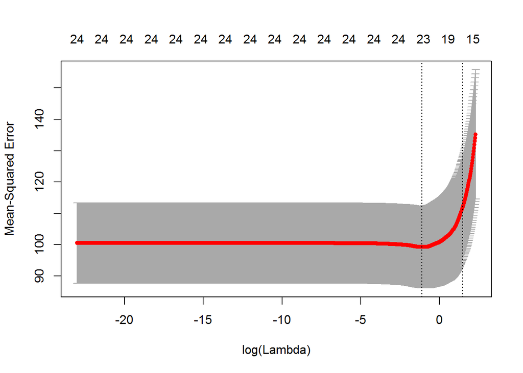

The min lambda is: `0.3262222`, mean square error: `113.2407655`.

From above analysis we can surely say that the mean square error is the lowest for The Ridge Regression - that is why we chose this one to predict the number of new cases of cancer in Stage $4$.

# 3 Let’s see predicted data on the map!

In this chapter we predicted the number of new cases in Stage 4 and shown it on the map of Poland divided into voivodeships. We chose the age group: **$54-65$**.

Firstly we presented the number of cases in Stage $4$ in $2012$ from age group: $54-65$. Then we predicted new diseases in Stage $4$. Let’s see it on the maps:

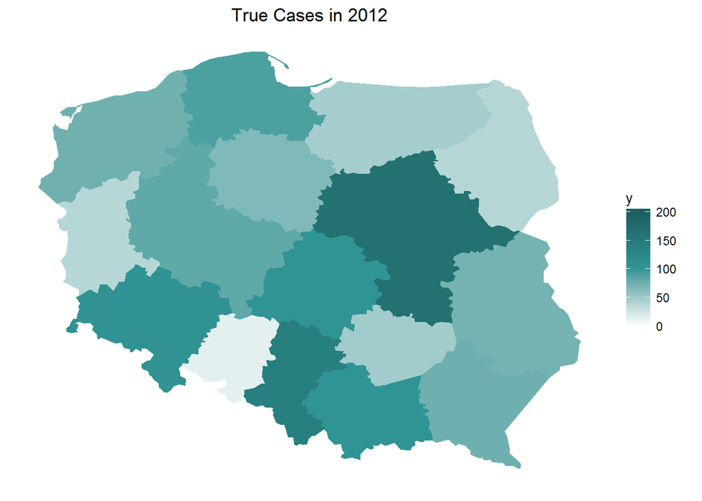

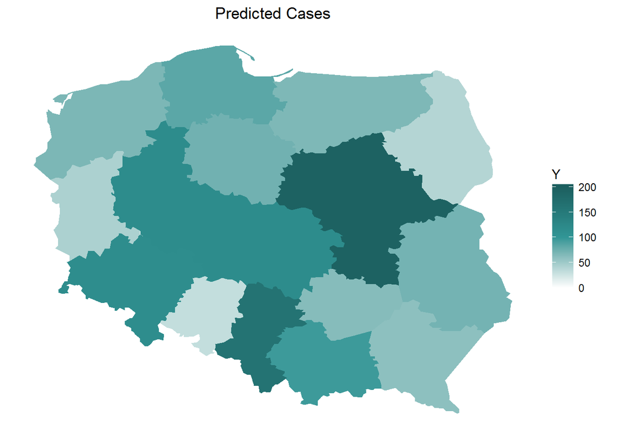

We predict that the number of new cases in stadium $4$ will grow in voivodeships such as: Wielkopolskie and Warmińsko-Mazurskie. An opposite is in voivodeship Pomorskie and Podkarpackie. In those regions will be observed fall with cancer in stage $4$.

# 4 Looking for new inputs

Now we focuse on finding new interesting factors, which can contribute to cancer disease and influence in future cancer risk.

We used data from BANK DANYCH LOKALNYCH. We noticed that we can use data widespread available such as:

1. Gaseous pollution
2. Dust pollution
3. Salaries

Each of them concern years: $2010$, $2011$, $2012$. Gaseous and dust pollution are together air pollution. This data contains information about the number of different pollution in each counties. Salaries is a data which contain average salary for each county.

First, we prepared our three additionaly data sets to make them useful during prediction. Data about air pollution was normalized - divided by area of each county.

From data concernig cancer diseases we chose, like before, breast cancer, thyroid and ovarian cancer. Additionaly the number of new cases was normalized - divided by the number of population in each county.

Finally, after merging all extra information, we’ve got data frame:

```
##    rok TERYT wynagrodzenia dwutlenek.siarki tlenki.azotu tlenek.węgla
## 1 2010  1001       3958.40     52.426650000 44.413220000  8.739669000
## 2 2010  1002       2748.82      0.618940200  0.225479100  0.475761000
## 3 2010  1003       2340.75      0.064724920  0.025889970  0.088996760
## 4 2010  1004       2828.64      0.002587322  0.001293661  0.003880983
## 5 2010  1005       2582.14      0.171052600  0.075910930  0.186234800
## 6 2010  1006       2447.97      0.072000000  0.022000000  0.030000000
##        pył     newcases
## 1 1.970000 0.0005927210
## 2 0.210000 0.0006926221
## 3 0.020000 0.0004518220
## 4 0.801365 0.0006277344
## 5 0.060000 0.0006154528
## 6 0.010000 0.0007060173
```

After preparations we can jump to prediction.

We wanted to predict the number of new cases of breast cancer, thyroid and ovarian cancer, using inputs such as: average salaries, air pollution with: sulphur dioxide, nitric oxide, carbon monoxide and dust.

**Ridge regression:**

To perform prediction we split data into train and test set. For train set we chose observations from $2010$ and $2011$. For test set observations from $2012$.

```r
predData$newcases <- 1000*predData$newcases
trainSet <- predData[predData$rok %in% c(2010, 2011), ]
testSet <- predData[predData$rok == 2012, ]
```

We used ridge regression for prediction:

```r
modelRidge <- cv.glmnet(as.matrix(trainSet[, 2:7]), as.vector(trainSet$newcases), alpha = 0)
preds <- predict(modelRidge, as.matrix(testSet[, 2:7]), s="lambda.min")
names(preds) <- testSet$TERYT
mse1 <- mean((preds-testSet[, 8])^2)
```

And we got prediction:

```
##             1
## 762 0.9012728
## 763 0.6785858
## 764 0.6234050
## 765 0.6839054
## 766 0.6555982
## 767 0.6354464
```

MSE for this model is: `0.0843968`.

Let’s see the prediction on map:

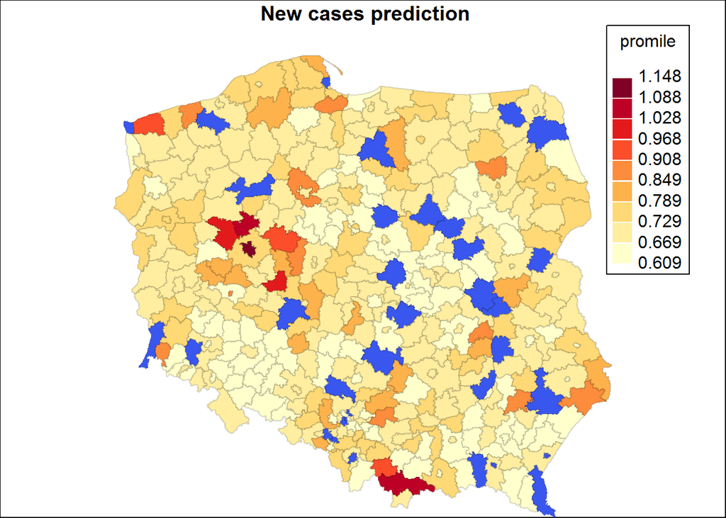

The area for which we don’t have a data is dark-blue. We can see that the counties: nowotarski and suski (woj. Małopolskie), szamotulski, obornicki, jarociński, Poznań (woj. Wielkopolskie) and kamieński (woj. Zachodnio-Pomorskie) are in danger. There is predicted the biggest number of new cases.

# 5 Appendix

**k-Nearest Neighbors**

We used also one more method for prediction - kNN. For this algorithm we took mean from $5$ nearest counties.

And after performing prediction we could calculate MSE: `0.1081341`

We want to collate the mse for ridge and kNN method and standard deviation for normalized new cases in $2012$.

MSE for ridge is: `0.0843968`.

MSE for kNN is: `0.1081341`.

Standard deviation is: `0.284196`.

At the end we visualised also the prediction for kNN method:

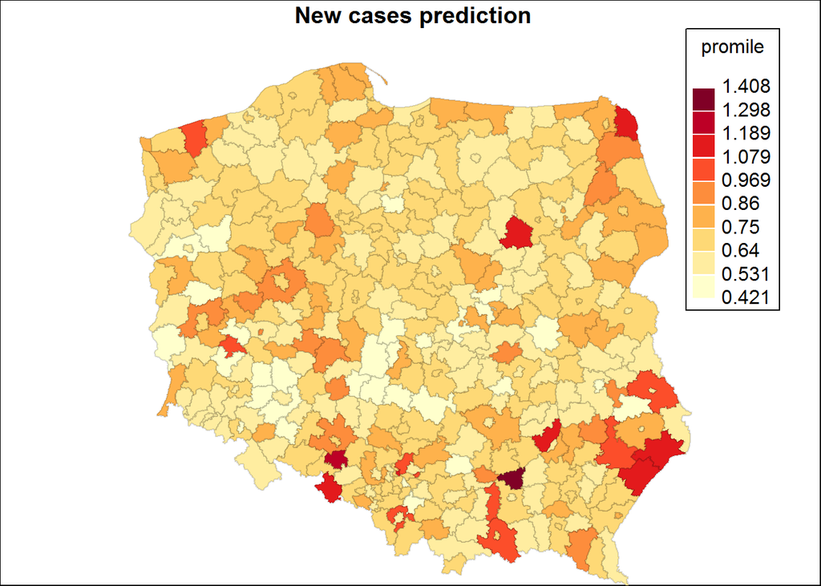

# 6 Bibliography

https://web.stanford.edu/~hastie/glmnet/glmnet_alpha.html

https://topepo.github.io/caret/modelList.html

https://bdl.stat.gov.pl/BDL/start

https://en.wikipedia.org/wiki/K-nearest_neighbors_algorithm